```python
import pandas as pd
import numpy as np
import os

import matplotlib.pyplot as plt
plt.rcParams['figure.figsize'] = (10, 5)
```

# Lecture 3 – More Pandas 🐼🐼

## DSC 80, Spring 2022

### Announcements

- Lab 1 is due on **Monday, April 4th at 11:59PM**.
  - Watch [this video 🎥](https://youtu.be/FpTo4AM9B30) for setup instructions.
- Discussion 1 is due for extra credit **tomorrow at 11:59PM**.
  - See [this post](https://campuswire.com/c/G325FA25B/feed/72) for a discussion on rounding errors.
  - Discussion podcasts appear alongside lecture podcasts at podcast.ucsd.edu – look for "A01" or "B01".
- Please submit the [Welcome + Alternate Exams Form](https://docs.google.com/forms/d/e/1FAIpQLSdBKLcPs4Xi0plaIw0MVZ0DyGcvnSZyHxKVC7S7LwEiCchepQ/viewform) by Monday.
- Project 1 will be released over the weekend.
  - The Checkpoint is due on **Thursday, April 7th at 11:59PM**.
  - The whole project is due on **Thursday, April 14th at 11:59PM**.

### Agenda

- `loc` and `iloc`.
- `pandas` and `numpy`.
- Useful Series and DataFrame methods.

## `loc` and `iloc`

```python
enrollments = pd.DataFrame({
    'Name': ['Granger, Hermione', 'Potter, Harry', 'Weasley, Ron', 'Longbottom, Neville'],
    'PID': ['A13245986', 'A17645384', 'A32438694', 'A52342436'],
    'LVL': [1, 1, 1, 1]
})

enrollments
```

|  | Name | PID | LVL |
| --- | --- | --- | --- |
| 0 | Granger, Hermione | A13245986 | 1 |
| 1 | Potter, Harry | A17645384 | 1 |
| 2 | Weasley, Ron | A32438694 | 1 |
| 3 | Longbottom, Neville | A52342436 | 1 |

### Selecting columns and rows simultaneously

So far, we used `[]` to select columns and `loc` to select rows.

```python
enrollments.loc[enrollments['Name'] < 'M']['PID']
```

```
0    A13245986
3    A52342436
Name: PID, dtype: object
```

### Selecting columns and rows simultaneously

`loc` can also be used to select both rows and columns. The general pattern is:

```
df.loc[<row selector>, <column selector>]
```

Examples:

- `df.loc[idx_list, col_list]` returns a DataFrame containing the rows in `idx_list` and columns in `col_list`.
- `df.loc[bool_arr, col_list]` returns a DataFrame contaning the rows for which `bool_arr` is `True` and columns in `col_list`.
- If `:` is used as the first input, all rows are kept. If `:` is used as the second input, all columns are kept.

```python
enrollments
```

|  | Name | PID | LVL |
| --- | --- | --- | --- |
| 0 | Granger, Hermione | A13245986 | 1 |
| 1 | Potter, Harry | A17645384 | 1 |
| 2 | Weasley, Ron | A32438694 | 1 |
| 3 | Longbottom, Neville | A52342436 | 1 |

```python
enrollments.loc[enrollments['Name'] < 'M', 'PID']
```

```
0    A13245986
3    A52342436
Name: PID, dtype: object
```

```python
enrollments.loc[enrollments['Name'] < 'M', ['PID']]
```

|  | PID |
| --- | --- |
| 0 | A13245986 |
| 3 | A52342436 |

### Even more ways of selecting rows and columns

In `df.loc[<row selection>, <column selection>]`:

- Both the first and second inputs can be Boolean sequences.
- Both the first and second inputs can be **slices**, which use `:` syntax (e.g. `0:2`, `'Name': 'PID'`).
- If both the first and second inputs are primitives (strings or numbers), the result is a single value, not a DataFrame or Series.
- The first input can be a **function** that takes a row as input and returns a Boolean.

There are many, many more – see the [`pandas` documentation](https://pandas.pydata.org/docs/user_guide/index.html#user-guide) for more.

```python
enrollments
```

|  | Name | PID | LVL |
| --- | --- | --- | --- |
| 0 | Granger, Hermione | A13245986 | 1 |
| 1 | Potter, Harry | A17645384 | 1 |
| 2 | Weasley, Ron | A32438694 | 1 |
| 3 | Longbottom, Neville | A52342436 | 1 |

```python
enrollments.loc[2, 'LVL']
```

```
1
```

```python
enrollments.loc[0:2, 'Name':'PID']
```

|  | Name | PID |
| --- | --- | --- |
| 0 | Granger, Hermione | A13245986 |
| 1 | Potter, Harry | A17645384 |
| 2 | Weasley, Ron | A32438694 |

### Don't forget `iloc`!

- `iloc` stands for "integer location".
- `iloc` is like `loc`, but it selects rows and columns based off of integer positions only.

```python
enrollments
```

|  | Name | PID | LVL |
| --- | --- | --- | --- |
| 0 | Granger, Hermione | A13245986 | 1 |
| 1 | Potter, Harry | A17645384 | 1 |
| 2 | Weasley, Ron | A32438694 | 1 |
| 3 | Longbottom, Neville | A52342436 | 1 |

```python
enrollments.iloc[2:4, 0:2]
```

|  | Name | PID |
| --- | --- | --- |
| 2 | Weasley, Ron | A32438694 |
| 3 | Longbottom, Neville | A52342436 |

```python
other = enrollments.set_index('Name')
other
```

| Name | PID | LVL |
| --- | --- | --- |
| Granger, Hermione | A13245986 | 1 |
| Potter, Harry | A17645384 | 1 |
| Weasley, Ron | A32438694 | 1 |
| Longbottom, Neville | A52342436 | 1 |

```python
other.iloc[2]
```

```
PID    A32438694
LVL            1
Name: Weasley, Ron, dtype: object
```

```python
other.loc[2]
```

[output not shown]

### Practice Questions

Consider the DataFrame below.

```python
jack = pd.DataFrame({1: ['fee', 'fi'], '1': ['fo', 'fum']})
jack
```

|  | 1 | 1 |
| --- | --- | --- |
| 0 | fee | fo |
| 1 | fi | fum |

For each of the following pieces of code, predict what the output will be. Then, uncomment the line of code and see for yourself.

```python
# jack[1]
```

```python
# jack[[1]]
```

```python
# jack['1']
```

```python
# jack[[1, 1]]
```

```python
# jack.loc[1]
```

```python
# jack.loc[jack[1] == 'fo']
```

```python
# jack[1, ['1', 1]]
```

```python
# jack.loc[1, 1]
```

## Pandas and NumPy

[figure not shown]

### NumPy

- NumPy stands for "numerical Python". It is a commonly-used Python module that enables **fast** computation involving arrays and matrices.
- `numpy`'s main object is the **array**. In `numpy`, arrays are:
  - homogenous (all values are of the same type), and
  - (potentially) multi-dimensional.
- Computation in `numpy` is fast because
  - Much of it is implemented in C.
  - `numpy` arrays are stored more efficiently in memory than, say, Python lists.
- [This site](https://cloudxlab.com/blog/numpy-pandas-introduction/) provides a good overview of `numpy` arrays.

### `pandas` is built upon `numpy`

- A Series in `pandas` is a `numpy` array with an index.
- A DataFrame is like a dictionary of columns, each of which is a `numpy` array.
- Many operations in `pandas` are fast because they use `numpy`'s implementations.
- To access the array underlying a DataFrame or Series, use the `to_numpy` method.
  - ⚠️ Warning: `to_numpy` returns a view of the original object, not a copy! Read more in the [course notes](https://notes.dsc80.com/content/02/data-types.html#copies-and-views-in-pandas).
  - `.values` is a soon-to-be-deprecated version of `.to_numpy()`.

```python
arr = np.array([4, 2, 9, 15, -1])
arr
```

```
array([ 4,  2,  9, 15, -1])
```

```python
ser = pd.Series(arr, index='a b c d e'.split(' '))
ser
```

```
a     4
b     2
c     9
d    15
e    -1
dtype: int64
```

```python
conv = ser.to_numpy()
conv
```

```
array([ 4,  2,  9, 15, -1])
```

```python
conv[2] = 100
conv
```

```
array([  4,   2, 100,  15,  -1])
```

```python
ser
```

```
a      4
b      2
c    100
d     15
e     -1
dtype: int64
```

### The dangers of `for`-loops

- `for`-loops are slow when processing large datasets.
- To illustrate how much faster `numpy` arithmetic is than using a `for`-loop, let's compute the distances between the origin $(0, 0)$ and 2000 random points $(x, y)$ in $\mathbb{R}^2$:
  - Using a `for`-loop.
  - Using vectorized arithmetic (through `numpy`).

### Aside: generating data

- First, we need to create a DataFrame containing 2000 random points in 2D.
- `np.random.random(N)` returns an array containing `N` numbers selected uniformly at random from the interval $[0, 1)$.

```python
N = 2000
x_arr = np.random.random(N)
y_arr = np.random.random(N)

coordinates = pd.DataFrame({"x": x_arr, "y": y_arr})
coordinates.head()
```

|  | x | y |
| --- | --- | --- |
| 0 | 0.155402 | 0.346735 |
| 1 | 0.922027 | 0.746329 |
| 2 | 0.855037 | 0.630200 |
| 3 | 0.755672 | 0.849689 |
| 4 | 0.518506 | 0.177432 |

Next, let's define a function that takes in a DataFrame like the one above and returns the distances between each point and the origin, using a `for`-loop.

```python
def distances(df):
    hyp_list = []
    for i in df.index:
        dist = (df.loc[i, 'x'] ** 2 + df.loc[i, 'y'] ** 2) ** 0.5
        hyp_list.append(dist)
    return hyp_list
```

The `%timeit` magic command can repeatedly run any snippet of code and give us its average runtime.

```python
%timeit distances(coordinates)
```

```
20.3 ms ± 197 µs per loop (mean ± std. dev. of 7 runs, 10 loops each)
```

Now, using a vectorized approach:

```python
%timeit (coordinates['x'] ** 2 + coordinates['y'] ** 2) ** 0.5
```

```
136 µs ± 752 ns per loop (mean ± std. dev. of 7 runs, 10000 loops each)
```

Note that "µs" refers to microseconds, which are one-millionth of a second, whereas "ms" refers to milliseconds, which are one-thousandth of a second.

**Takeaway:** avoid `for`-loops whenever possible!

### `pandas` data types

- A **data type** in `pandas` refers to the type of values in a column.
- A column's data type determines which operations can be applied to it.
- `pandas` tries to guess the correct data type for a given DataFrame, and is often wrong.
  - This can lead to incorrect calculations and poor memory/time performance.
- As a result, you will often need to explicitly convert between data types.

### `pandas` data types

| Pandas dtype | Python type | NumPy type | SQL type | Usage |
| --- | --- | --- | --- | --- |
| int64 | int | int_, int8,...,int64, uint8,...,uint64 | INT, BIGINT | Integer numbers |
| float64 | float | float_, float16, float32, float64 | FLOAT | Floating point numbers |
| bool | bool | bool_ | BOOL | True/False values |
| datetime64 | NA | datetime64[ns] | DATETIME | Date and time values |
| timedelta[ns] | NA | NA | NA | Differences between two datetimes |
| category | NA | NA | ENUM | Finite list of text values |
| object | str | string, unicode | NA | Text |
| object | NA | object | NA | Mixed types |

[This article](https://www.dataquest.io/blog/pandas-big-data/) details how `pandas` stores different data types under the hood.

### Type conversion and the underlying `numpy` array(s)

- The `dtypes` attribute (of both Series and DataFrames) describes the data type of each column.
- The `to_numpy` method, when used on a Series, returns an array in which all values are of the data type specified by `dtypes`.
- The `to_numpy` method, when used on a DataFrame, returns a multi-dimensional array of type `object`, unless all columns in the DataFrame are homogenous.

```python
# Read in file
elections_fp = os.path.join('data', 'elections.csv')
elections = pd.read_csv(elections_fp)
elections.head()
```

|  | Candidate | Party | % | Year | Result |
| --- | --- | --- | --- | --- | --- |
| 0 | Reagan | Republican | 50.7 | 1980 | win |
| 1 | Carter | Democratic | 41.0 | 1980 | loss |
| 2 | Anderson | Independent | 6.6 | 1980 | loss |
| 3 | Reagan | Republican | 58.8 | 1984 | win |
| 4 | Mondale | Democratic | 37.6 | 1984 | loss |

```python
elections.dtypes
```

```
Candidate     object
Party         object
%            float64
Year           int64
Result        object
dtype: object
```

```python
elections['Year'].dtypes
```

```
dtype('int64')
```

```python
elections['Year'].to_numpy().dtype
```

```
dtype('int64')
```

```python
elections.to_numpy()
```

```
array([['Reagan', 'Republican', 50.7, 1980, 'win'],
       ['Carter', 'Democratic', 41.0, 1980, 'loss'],
       ['Anderson', 'Independent', 6.6, 1980, 'loss'],
       ['Reagan', 'Republican', 58.8, 1984, 'win'],
       ['Mondale', 'Democratic', 37.6, 1984, 'loss'],
       ['Bush', 'Republican', 53.4, 1988, 'win'],
       ['Dukakis', 'Democratic', 45.6, 1988, 'loss'],
       ['Clinton', 'Democratic', 43.0, 1992, 'win'],
       ['Bush', 'Republican', 37.4, 1992, 'loss'],
       ['Perot', 'Independent', 18.9, 1992, 'loss'],
       ['Clinton', 'Democratic', 49.2, 1996, 'win'],
       ['Dole', 'Republican', 40.7, 1996, 'loss'],
       ['Perot', 'Independent', 8.4, 1996, 'loss'],
       ['Gore', 'Democratic', 48.4, 2000, 'loss'],
       ['Bush', 'Republican', 47.9, 2000, 'win'],
       ['Kerry', 'Democratic', 48.3, 2004, 'loss'],
       ['Bush', 'Republican', 50.7, 2004, 'win'],
       ['Obama', 'Democratic', 52.9, 2008, 'win'],
       ['McCain', 'Republican', 45.7, 2008, 'loss'],
       ['Obama', 'Democratic', 51.1, 2012, 'win'],
       ['Romney', 'Republican', 47.2, 2012, 'loss'],
       ['Clinton', 'Democratic', 48.2, 2016, 'loss'],
       ['Trump', 'Republican', 46.1, 2016, 'win'],
       ['Biden', 'Democratic', 51.3, 2020, 'win'],
       ['Trump', 'Republican', 46.9, 2020, 'loss']], dtype=object)
```

What do you think is happening here?

```python
elections['Year'] ** 7
```

```
0    -9176136658659852288
1    -9176136658659852288
2    -9176136658659852288
3    -8884621300430012416
4    -8884621300430012416
5    -6382217169766957056
6    -6382217169766957056
7    -1459841187188834304
8    -1459841187188834304
9    -1459841187188834304
10    6093279273289170944
11    6093279273289170944
12    6093279273289170944
13   -1957127470578663424
14   -1957127470578663424
15   -6950134928041361408
16   -6950134928041361408
17   -8669840355176218624
18   -8669840355176218624
19   -6898610338587885568
20   -6898610338587885568
21   -1417070411446747136
22   -1417070411446747136
23    7995905371925528576
24    7995905371925528576
Name: Year, dtype: int64
```

### ⚠️ Warning: `numpy` and `pandas` don't always make the same decisions!

`numpy` prefers homogenous data types to optimize memory and read/write speed. This leads to **type coercion**. Notice that the array created below contains only strings, even though there was an `int` in the argument list.

```python
np.array(['a', 1])
```

```
array(['a', '1'], dtype='<U21')
```

On the other hand, `pandas` likes correctness and ease-of-use. The Series created below is of type `object`, which preserves the original data types in the argument list.

```python
pd.Series(['a', 1])
```

```
0    a
1    1
dtype: object
```

```python
pd.Series(['a', 1]).values
```

```
array(['a', 1], dtype=object)
```

You can specify the data type of an array when initializing it by using the `dtype` argument.

```python
np.array(['a', 1], dtype=object)
```

```
array(['a', 1], dtype=object)
```

`pandas` does make some trade-offs for efficiency, however. For instance, a Series consisting of both `int`s and `float`s is coerced to the `float64` data type.

```python
pd.Series([1, 1.0])
```

```
0    1.0
1    1.0
dtype: float64
```

### Type conversion

You can change the data type of a Series using the `.astype` Series method.

```python
ser = pd.Series(['1', '2', '3', '4'])
ser
```

```
0    1
1    2
2    3
3    4
dtype: object
```

```python
ser.astype(int)
```

```
0    1
1    2
2    3
3    4
dtype: int64
```

```python
ser.astype(float)
```

```
0    1.0
1    2.0
2    3.0
3    4.0
dtype: float64
```

### Performance and memory management

As we just discovered,

- `numpy` is optimized for speed and memory consumption.
- `pandas` makes implementation choices that:
  - are slow and use a lot of memory, but
  - optimize for fast code development.

To demonstrate, let's create a large array in which all of the entries are non-negative numbers less than 255, meaning that they can be represented with 8 bits (i.e. as `np.uint8`s, where the "u" stands for "unsigned").

```python
import random
data = np.random.choice(np.arange(8), 10 ** 6)
```

When we tell `pandas` to use a `dtype` of `uint8`, the size of the resulting DataFrame is under a megabyte.

```python
ser1 = pd.Series(data, dtype=np.uint8).to_frame()
ser1.info()
```

```
<class 'pandas.core.frame.DataFrame'>
RangeIndex: 1000000 entries, 0 to 999999
Data columns (total 1 columns):
 #   Column  Non-Null Count    Dtype
---  ------  --------------    -----
 0   0       1000000 non-null  uint8
dtypes: uint8(1)
memory usage: 976.7 KB
```

But by default, even though the numbers are only 8-bit, `pandas` uses the `int64` dtype, and the resulting DataFrame is over 7 megabytes large.

```python
ser2 = pd.Series(data).to_frame()
ser2.info()
```

```
<class 'pandas.core.frame.DataFrame'>
RangeIndex: 1000000 entries, 0 to 999999
Data columns (total 1 columns):
 #   Column  Non-Null Count    Dtype
---  ------  --------------    -----
 0   0       1000000 non-null  int64
dtypes: int64(1)
memory usage: 7.6 MB
```

## Useful Series and DataFrame methods

### Shared methods and attributes

- The `head`/`tail` methods return the first/last few rows (the default is 5).
- The `shape` attribute returns the number of rows (and columns).
- The `size` attribute returns the number of entries.

```python
elections.head()
```

|  | Candidate | Party | % | Year | Result |
| --- | --- | --- | --- | --- | --- |
| 0 | Reagan | Republican | 50.7 | 1980 | win |
| 1 | Carter | Democratic | 41.0 | 1980 | loss |
| 2 | Anderson | Independent | 6.6 | 1980 | loss |
| 3 | Reagan | Republican | 58.8 | 1984 | win |
| 4 | Mondale | Democratic | 37.6 | 1984 | loss |

```python
elections.shape
```

```
(25, 5)
```

```python
elections.size
```

```
125
```

### Series methods

| Method Name | Description |
| --- | --- |
| `count` | Returns the number of non-null entries in the Series |
| `unique` | Returns the unique values in the Series |
| `nunique` | Returns the number of unique values in the Series |
| `value_counts` | Returns a Series of counts of unique values |
| `describe` | Returns a Series of descriptive stats of values |

```python
elections.head()
```

|  | Candidate | Party | % | Year | Result |
| --- | --- | --- | --- | --- | --- |
| 0 | Reagan | Republican | 50.7 | 1980 | win |
| 1 | Carter | Democratic | 41.0 | 1980 | loss |
| 2 | Anderson | Independent | 6.6 | 1980 | loss |
| 3 | Reagan | Republican | 58.8 | 1984 | win |
| 4 | Mondale | Democratic | 37.6 | 1984 | loss |

```python
# Distinct candidates
elections['Candidate'].unique()
```

```
array(['Reagan', 'Carter', 'Anderson', 'Mondale', 'Bush', 'Dukakis',
       'Clinton', 'Perot', 'Dole', 'Gore', 'Kerry', 'Obama', 'McCain',
       'Romney', 'Trump', 'Biden'], dtype=object)
```

```python
# Number of distinct candidates
elections['Candidate'].nunique()
```

```
16
```

```python
# Total number of candidates
elections['Candidate'].count()
```

```
25
```

```python
# 🤔
republicans = elections.loc[elections['Party'] == 'Republican']
republicans['Result'].value_counts()
```

```
win     6
loss    5
Name: Result, dtype: int64
```

```python
republicans['%'].describe()
```

```
count    11.000000
mean     47.772727
std       5.798464
min      37.400000
25%      45.900000
50%      47.200000
75%      50.700000
max      58.800000
Name: %, dtype: float64
```

### DataFrame methods

- DataFrames share *many* of the same methods with Series.
  - In such cases, the DataFrame method applies the Series method to every row or column.
- Some DataFrame methods accept the `axis` keyword argument:
  - `axis=0`: the method is applied across the rows (i.e. to each column).
  - `axis=1`: the method is applied across the columns (i.e. to each row).
- Default value: `axis=0`.

```python
elections.head()
```

|  | Candidate | Party | % | Year | Result |
| --- | --- | --- | --- | --- | --- |
| 0 | Reagan | Republican | 50.7 | 1980 | win |
| 1 | Carter | Democratic | 41.0 | 1980 | loss |
| 2 | Anderson | Independent | 6.6 | 1980 | loss |
| 3 | Reagan | Republican | 58.8 | 1984 | win |
| 4 | Mondale | Democratic | 37.6 | 1984 | loss |

```python
elections[['%', 'Year']].mean()
```

```
%         43.04
Year    1998.72
dtype: float64
```

The following piece of code works, but is meaningless. Why?

```python
elections[['%', 'Year']].mean(axis=1)
```

```
0     1015.35
1     1010.50
2      993.30
3     1021.40
4     1010.80
5     1020.70
6     1016.80
7     1017.50
8     1014.70
9     1005.45
10    1022.60
11    1018.35
12    1002.20
13    1024.20
14    1023.95
15    1026.15
16    1027.35
17    1030.45
18    1026.85
19    1031.55
20    1029.60
21    1032.10
22    1031.05
23    1035.65
24    1033.45
dtype: float64
```

### Even more DataFrame methods

| Method Name | Description |
| --- | --- |
| `sort_values` | Returns a DataFrame sorted by the specified column |
| `drop_duplicates` | Returns a DataFrame with duplicate values dropped |
| `describe` | Returns descriptive stats of the DataFrame |

```python
elections.sort_values('%', ascending=False).head(4)
```

|  | Candidate | Party | % | Year | Result |
| --- | --- | --- | --- | --- | --- |
| 3 | Reagan | Republican | 58.8 | 1984 | win |
| 5 | Bush | Republican | 53.4 | 1988 | win |
| 17 | Obama | Democratic | 52.9 | 2008 | win |
| 23 | Biden | Democratic | 51.3 | 2020 | win |

```python
# By default, drop_duplicates looks for duplicate entire rows, which elections does not have
elections.drop_duplicates(subset=['Candidate'])
```

|  | Candidate | Party | % | Year | Result |
| --- | --- | --- | --- | --- | --- |
| 0 | Reagan | Republican | 50.7 | 1980 | win |
| 1 | Carter | Democratic | 41.0 | 1980 | loss |
| 2 | Anderson | Independent | 6.6 | 1980 | loss |
| 4 | Mondale | Democratic | 37.6 | 1984 | loss |
| 5 | Bush | Republican | 53.4 | 1988 | win |
| 6 | Dukakis | Democratic | 45.6 | 1988 | loss |
| 7 | Clinton | Democratic | 43.0 | 1992 | win |
| 9 | Perot | Independent | 18.9 | 1992 | loss |
| 11 | Dole | Republican | 40.7 | 1996 | loss |
| 13 | Gore | Democratic | 48.4 | 2000 | loss |
| 15 | Kerry | Democratic | 48.3 | 2004 | loss |
| 17 | Obama | Democratic | 52.9 | 2008 | win |
| 18 | McCain | Republican | 45.7 | 2008 | loss |
| 20 | Romney | Republican | 47.2 | 2012 | loss |
| 22 | Trump | Republican | 46.1 | 2016 | win |
| 23 | Biden | Democratic | 51.3 | 2020 | win |

```python
elections.describe()
```

|  | % | Year |
| --- | --- | --- |
| count | 25.000000 | 25.000000 |
| mean | 43.040000 | 1998.720000 |
| std | 13.046136 | 12.843675 |
| min | 6.600000 | 1980.000000 |
| 25% | 41.000000 | 1988.000000 |
| 50% | 47.200000 | 1996.000000 |
| 75% | 50.700000 | 2008.000000 |
| max | 58.800000 | 2020.000000 |

### Adding and modifying columns, using a copy

- To add a new column to a DataFrame, use the `assign` method.
- To add a new row to a DataFrame, use the `append` method.
- Both `assign` and `append` return a copy of the DataFrame, **which is a great feature!**
- To change the values in a column, re-assign its name to a sequence of the desired values.

As an aside, you should try your best to write **chained** `pandas` code, as follows:

```python
(
    elections
    .assign(proportion_of_vote=(elections['%'] / 100))
    .head()
)
```

|  | Candidate | Party | % | Year | Result | proportion_of_vote |
| --- | --- | --- | --- | --- | --- | --- |
| 0 | Reagan | Republican | 50.7 | 1980 | win | 0.507 |
| 1 | Carter | Democratic | 41.0 | 1980 | loss | 0.410 |
| 2 | Anderson | Independent | 6.6 | 1980 | loss | 0.066 |
| 3 | Reagan | Republican | 58.8 | 1984 | win | 0.588 |
| 4 | Mondale | Democratic | 37.6 | 1984 | loss | 0.376 |

You can chain together several steps at a time:

```python
(
    elections
    .assign(proportion_of_vote=(elections['%'] / 100))
    .assign(Result=elections['Result'].str.upper())
    .head()
)
```

|  | Candidate | Party | % | Year | Result | proportion_of_vote |
| --- | --- | --- | --- | --- | --- | --- |
| 0 | Reagan | Republican | 50.7 | 1980 | WIN | 0.507 |
| 1 | Carter | Democratic | 41.0 | 1980 | LOSS | 0.410 |
| 2 | Anderson | Independent | 6.6 | 1980 | LOSS | 0.066 |
| 3 | Reagan | Republican | 58.8 | 1984 | WIN | 0.588 |
| 4 | Mondale | Democratic | 37.6 | 1984 | LOSS | 0.376 |

You can also use `assign` when the desired column name has spaces, by using keyword arguments.

```python
(
    elections
    .assign(**{'Proportion of Vote': elections['%'] / 100})
    .head()
)
```

|  | Candidate | Party | % | Year | Result | Proportion of Vote |
| --- | --- | --- | --- | --- | --- | --- |
| 0 | Reagan | Republican | 50.7 | 1980 | win | 0.507 |
| 1 | Carter | Democratic | 41.0 | 1980 | loss | 0.410 |
| 2 | Anderson | Independent | 6.6 | 1980 | loss | 0.066 |
| 3 | Reagan | Republican | 58.8 | 1984 | win | 0.588 |
| 4 | Mondale | Democratic | 37.6 | 1984 | loss | 0.376 |

### ⚠️ Warning!

- Adding a row with `append` has terrible time complexity!
- Use it sparingly.
- Specifically, don't build a DataFrame using `append` in a loop.

### Adding and modifying columns, in-place

- You can assign a new row or column to a DataFrame **in-place** using `loc` or `[]`.
  - Works like dictionary assignment.
  - Unlike `assign`, this **modifies** the underlying DataFrame rather than a copy of it.
- This is the more "common" way of adding/modifying columns.
  - ⚠️ Warning: Exercise caution when using this approach, since this approach changes the values of existing variables.

```python
# By default, .copy() returns a deep copy of the object it is called on,
# meaning that if you change the copy the original remains unmodified.
mod_elec = elections.copy()
mod_elec.head()
```

|  | Candidate | Party | % | Year | Result |
| --- | --- | --- | --- | --- | --- |
| 0 | Reagan | Republican | 50.7 | 1980 | win |
| 1 | Carter | Democratic | 41.0 | 1980 | loss |
| 2 | Anderson | Independent | 6.6 | 1980 | loss |
| 3 | Reagan | Republican | 58.8 | 1984 | win |
| 4 | Mondale | Democratic | 37.6 | 1984 | loss |

```python
mod_elec['Proportion of Vote'] = mod_elec['%'] / 100
mod_elec.head()
```

|  | Candidate | Party | % | Year | Result | Proportion of Vote |
| --- | --- | --- | --- | --- | --- | --- |
| 0 | Reagan | Republican | 50.7 | 1980 | win | 0.507 |
| 1 | Carter | Democratic | 41.0 | 1980 | loss | 0.410 |
| 2 | Anderson | Independent | 6.6 | 1980 | loss | 0.066 |
| 3 | Reagan | Republican | 58.8 | 1984 | win | 0.588 |
| 4 | Mondale | Democratic | 37.6 | 1984 | loss | 0.376 |

```python
mod_elec['Result'] = mod_elec['Result'].str.upper()
mod_elec.head()
```

|  | Candidate | Party | % | Year | Result | Proportion of Vote |
| --- | --- | --- | --- | --- | --- | --- |
| 0 | Reagan | Republican | 50.7 | 1980 | WIN | 0.507 |
| 1 | Carter | Democratic | 41.0 | 1980 | LOSS | 0.410 |
| 2 | Anderson | Independent | 6.6 | 1980 | LOSS | 0.066 |
| 3 | Reagan | Republican | 58.8 | 1984 | WIN | 0.588 |
| 4 | Mondale | Democratic | 37.6 | 1984 | LOSS | 0.376 |

```python
# 🤔
mod_elec.loc[-1, :] = ['Carter', 'Democratic', 50.1, 1976, 'WIN', 0.501]
mod_elec.loc[-2, :] = ['Ford', 'Republican', 48.0, 1976, 'LOSS', 0.48]
mod_elec
```

|  | Candidate | Party | % | Year | Result | Proportion of Vote |
| --- | --- | --- | --- | --- | --- | --- |
| 0 | Reagan | Republican | 50.7 | 1980.0 | WIN | 0.507 |
| 1 | Carter | Democratic | 41.0 | 1980.0 | LOSS | 0.410 |
| 2 | Anderson | Independent | 6.6 | 1980.0 | LOSS | 0.066 |
| 3 | Reagan | Republican | 58.8 | 1984.0 | WIN | 0.588 |
| 4 | Mondale | Democratic | 37.6 | 1984.0 | LOSS | 0.376 |
| 5 | Bush | Republican | 53.4 | 1988.0 | WIN | 0.534 |
| 6 | Dukakis | Democratic | 45.6 | 1988.0 | LOSS | 0.456 |
| 7 | Clinton | Democratic | 43.0 | 1992.0 | WIN | 0.430 |
| 8 | Bush | Republican | 37.4 | 1992.0 | LOSS | 0.374 |
| 9 | Perot | Independent | 18.9 | 1992.0 | LOSS | 0.189 |
| 10 | Clinton | Democratic | 49.2 | 1996.0 | WIN | 0.492 |
| 11 | Dole | Republican | 40.7 | 1996.0 | LOSS | 0.407 |
| 12 | Perot | Independent | 8.4 | 1996.0 | LOSS | 0.084 |
| 13 | Gore | Democratic | 48.4 | 2000.0 | LOSS | 0.484 |
| 14 | Bush | Republican | 47.9 | 2000.0 | WIN | 0.479 |
| 15 | Kerry | Democratic | 48.3 | 2004.0 | LOSS | 0.483 |
| 16 | Bush | Republican | 50.7 | 2004.0 | WIN | 0.507 |
| 17 | Obama | Democratic | 52.9 | 2008.0 | WIN | 0.529 |
| 18 | McCain | Republican | 45.7 | 2008.0 | LOSS | 0.457 |
| 19 | Obama | Democratic | 51.1 | 2012.0 | WIN | 0.511 |
| 20 | Romney | Republican | 47.2 | 2012.0 | LOSS | 0.472 |
| 21 | Clinton | Democratic | 48.2 | 2016.0 | LOSS | 0.482 |
| 22 | Trump | Republican | 46.1 | 2016.0 | WIN | 0.461 |
| 23 | Biden | Democratic | 51.3 | 2020.0 | WIN | 0.513 |
| 24 | Trump | Republican | 46.9 | 2020.0 | LOSS | 0.469 |
| -1 | Carter | Democratic | 50.1 | 1976.0 | WIN | 0.501 |
| -2 | Ford | Republican | 48.0 | 1976.0 | LOSS | 0.480 |

```python
mod_elec = mod_elec.sort_index()
mod_elec.head()
```

|  | Candidate | Party | % | Year | Result | Proportion of Vote |
| --- | --- | --- | --- | --- | --- | --- |
| -2 | Ford | Republican | 48.0 | 1976.0 | LOSS | 0.480 |
| -1 | Carter | Democratic | 50.1 | 1976.0 | WIN | 0.501 |
| 0 | Reagan | Republican | 50.7 | 1980.0 | WIN | 0.507 |
| 1 | Carter | Democratic | 41.0 | 1980.0 | LOSS | 0.410 |
| 2 | Anderson | Independent | 6.6 | 1980.0 | LOSS | 0.066 |

```python
# df.reset_index(drop=True) drops the current index
# of the DataFrame and replaces it with an index of increasing integers
mod_elec.reset_index(drop=True)
```

|  | Candidate | Party | % | Year | Result | Proportion of Vote |
| --- | --- | --- | --- | --- | --- | --- |
| 0 | Ford | Republican | 48.0 | 1976.0 | LOSS | 0.480 |
| 1 | Carter | Democratic | 50.1 | 1976.0 | WIN | 0.501 |
| 2 | Reagan | Republican | 50.7 | 1980.0 | WIN | 0.507 |
| 3 | Carter | Democratic | 41.0 | 1980.0 | LOSS | 0.410 |
| 4 | Anderson | Independent | 6.6 | 1980.0 | LOSS | 0.066 |
| 5 | Reagan | Republican | 58.8 | 1984.0 | WIN | 0.588 |
| 6 | Mondale | Democratic | 37.6 | 1984.0 | LOSS | 0.376 |
| 7 | Bush | Republican | 53.4 | 1988.0 | WIN | 0.534 |
| 8 | Dukakis | Democratic | 45.6 | 1988.0 | LOSS | 0.456 |
| 9 | Clinton | Democratic | 43.0 | 1992.0 | WIN | 0.430 |
| 10 | Bush | Republican | 37.4 | 1992.0 | LOSS | 0.374 |
| 11 | Perot | Independent | 18.9 | 1992.0 | LOSS | 0.189 |
| 12 | Clinton | Democratic | 49.2 | 1996.0 | WIN | 0.492 |
| 13 | Dole | Republican | 40.7 | 1996.0 | LOSS | 0.407 |
| 14 | Perot | Independent | 8.4 | 1996.0 | LOSS | 0.084 |
| 15 | Gore | Democratic | 48.4 | 2000.0 | LOSS | 0.484 |
| 16 | Bush | Republican | 47.9 | 2000.0 | WIN | 0.479 |
| 17 | Kerry | Democratic | 48.3 | 2004.0 | LOSS | 0.483 |
| 18 | Bush | Republican | 50.7 | 2004.0 | WIN | 0.507 |
| 19 | Obama | Democratic | 52.9 | 2008.0 | WIN | 0.529 |
| 20 | McCain | Republican | 45.7 | 2008.0 | LOSS | 0.457 |
| 21 | Obama | Democratic | 51.1 | 2012.0 | WIN | 0.511 |
| 22 | Romney | Republican | 47.2 | 2012.0 | LOSS | 0.472 |
| 23 | Clinton | Democratic | 48.2 | 2016.0 | LOSS | 0.482 |
| 24 | Trump | Republican | 46.1 | 2016.0 | WIN | 0.461 |
| 25 | Biden | Democratic | 51.3 | 2020.0 | WIN | 0.513 |
| 26 | Trump | Republican | 46.9 | 2020.0 | LOSS | 0.469 |

## Example: San Diego employee salaries (again)

Note: We probably won't finish looking at all of this code in lecture, but we will leave it here for you as a reference.

### Reading the data

Let's work with the same dataset that we did in Lecture 1, using our new knowledge of `pandas`.

```python
salaries = pd.read_csv('https://transcal.s3.amazonaws.com/public/export/san-diego-2020.csv')
salaries['Employee Name'] = salaries['Employee Name'].str.split().str[0] + ' xxxxx'
```

```python
salaries.head()
```

|  | Employee Name | Job Title | Base Pay | Overtime Pay | Other Pay | Benefits | Total Pay | Total Pay & Benefits | Year | Notes | Agency | Status |
| --- | --- | --- | --- | --- | --- | --- | --- | --- | --- | --- | --- | --- |
| 0 | Michael xxxxx | Police Officer | 117691.0 | 187290.0 | 13331.00 | 36380.0 | 318312.0 | 354692.0 | 2020 | NaN | San Diego | FT |
| 1 | Gary xxxxx | Police Officer | 117691.0 | 160062.0 | 42946.00 | 31795.0 | 320699.0 | 352494.0 | 2020 | NaN | San Diego | FT |
| 2 | Eric xxxxx | Fire Engineer | 35698.0 | 204462.0 | 69121.00 | 38362.0 | 309281.0 | 347643.0 | 2020 | NaN | San Diego | PT |
| 3 | Gregg xxxxx | Retirement Administrator | 305000.0 | 0.0 | 12814.00 | 24792.0 | 317814.0 | 342606.0 | 2020 | NaN | San Diego | FT |
| 4 | Joseph xxxxx | Fire Battalion Chief | 94451.0 | 157778.0 | 48151.00 | 42096.0 | 300380.0 | 342476.0 | 2020 | NaN | San Diego | FT |

```python
salaries.info()
```

```
<class 'pandas.core.frame.DataFrame'>
RangeIndex: 12605 entries, 0 to 12604
Data columns (total 12 columns):
 #   Column                Non-Null Count  Dtype
---  ------                --------------  -----
 0   Employee Name         12605 non-null  object
 1   Job Title             12605 non-null  object
 2   Base Pay              12605 non-null  float64
 3   Overtime Pay          12605 non-null  float64
 4   Other Pay             12605 non-null  object
 5   Benefits              12605 non-null  float64
 6   Total Pay             12605 non-null  float64
 7   Total Pay & Benefits  12605 non-null  float64
 8   Year                  12605 non-null  int64
 9   Notes                 0 non-null      float64
 10  Agency                12605 non-null  object
 11  Status                12605 non-null  object
dtypes: float64(6), int64(1), object(5)
memory usage: 1.2+ MB
```

### Data cleaning

Current issues with the dataset:

- Some columns have no information (`'Notes'`) or the same value in all rows (`'Agency'`) – let's drop them.
- `'Other Pay'` should be numeric, but it's not currently.

```python
# Dropping useless columns
salaries = salaries.drop(['Year', 'Notes', 'Agency'], axis=1)
salaries.head()
```

|  | Employee Name | Job Title | Base Pay | Overtime Pay | Other Pay | Benefits | Total Pay | Total Pay & Benefits | Status |
| --- | --- | --- | --- | --- | --- | --- | --- | --- | --- |
| 0 | Michael xxxxx | Police Officer | 117691.0 | 187290.0 | 13331.00 | 36380.0 | 318312.0 | 354692.0 | FT |
| 1 | Gary xxxxx | Police Officer | 117691.0 | 160062.0 | 42946.00 | 31795.0 | 320699.0 | 352494.0 | FT |
| 2 | Eric xxxxx | Fire Engineer | 35698.0 | 204462.0 | 69121.00 | 38362.0 | 309281.0 | 347643.0 | PT |
| 3 | Gregg xxxxx | Retirement Administrator | 305000.0 | 0.0 | 12814.00 | 24792.0 | 317814.0 | 342606.0 | FT |
| 4 | Joseph xxxxx | Fire Battalion Chief | 94451.0 | 157778.0 | 48151.00 | 42096.0 | 300380.0 | 342476.0 | FT |

### Fixing the `'Other Pay'` column

```python
salaries['Other Pay'].dtype
```

```
dtype('O')
```

```python
salaries['Other Pay'].unique()
```

```
array(['13331.00', '42946.00', '69121.00', ..., '119.00', '47.00', '4.00'],
      dtype=object)
```

It appears that most of the values in the `'Other Pay'` column are strings containing numbers. Which values are not numbers?

```python
salaries.loc[-salaries['Other Pay'].str.contains('.00')]
```

|  | Employee Name | Job Title | Base Pay | Overtime Pay | Other Pay | Benefits | Total Pay | Total Pay & Benefits | Status |
| --- | --- | --- | --- | --- | --- | --- | --- | --- | --- |
| 10347 | Elmo xxxxx | Laborer | 27288.0 | 489.0 | Aggregate | 1103.0 | 27774.0 | 28877.0 | PT |
| 10624 | John xxxxx | Golf Operations Assistant | 19278.0 | 0.0 | Aggregate | 1157.0 | 19275.0 | 20432.0 | PT |
| 11988 | Benjamin xxxxx | Stock Clerk(Auto Parts Stock Clrk) | 1234.0 | 54.0 | Aggregate | 681.0 | 1285.0 | 1966.0 | PT |
| 12079 | Eric xxxxx | Traffic Signal Technician 1 | 0.0 | 1290.0 | Aggregate | 119.0 | 1287.0 | 1406.0 | PT |
| 12088 | Teshome xxxxx | Instrumentation & Control Tech | 0.0 | 1248.0 | Aggregate | 115.0 | 1245.0 | 1360.0 | PT |
| 12093 | Nicholas xxxxx | Deputy Chief Oper Ofcr | 1231.0 | 0.0 | Aggregate | 113.0 | 1228.0 | 1341.0 | PT |
| 12097 | Jonathan xxxxx | Laborer | 1198.0 | 0.0 | Aggregate | 110.0 | 1195.0 | 1305.0 | PT |
| 12098 | Gilberto xxxxx | Laborer | 1198.0 | 0.0 | Aggregate | 110.0 | 1195.0 | 1305.0 | PT |
| 12101 | Jason xxxxx | Plant Procs Cntrl Electrician | 0.0 | 1150.0 | Aggregate | 106.0 | 1147.0 | 1253.0 | PT |
| 12115 | Raynaldo xxxxx | Asoc Eng-Electrical | 0.0 | 1113.0 | Aggregate | 102.0 | 1110.0 | 1212.0 | PT |
| 12124 | Mario xxxxx | Heavy Truck Drvr 2 | 0.0 | 1068.0 | Aggregate | 98.0 | 1065.0 | 1163.0 | PT |
| 12142 | Ivan xxxxx | Utility Worker 1 | 0.0 | 1002.0 | Aggregate | 92.0 | 999.0 | 1091.0 | PT |

We can keep just the rows where the `'Other Pay'` is numeric, and then convert the `'Other Pay'` column to `float`.

```python
salaries = salaries.loc[salaries['Other Pay'].str.contains('.00') == True]
salaries['Other Pay'] = salaries['Other Pay'].astype(float)
salaries.head()
```

|  | Employee Name | Job Title | Base Pay | Overtime Pay | Other Pay | Benefits | Total Pay | Total Pay & Benefits | Status |
| --- | --- | --- | --- | --- | --- | --- | --- | --- | --- |
| 0 | Michael xxxxx | Police Officer | 117691.0 | 187290.0 | 13331.0 | 36380.0 | 318312.0 | 354692.0 | FT |
| 1 | Gary xxxxx | Police Officer | 117691.0 | 160062.0 | 42946.0 | 31795.0 | 320699.0 | 352494.0 | FT |
| 2 | Eric xxxxx | Fire Engineer | 35698.0 | 204462.0 | 69121.0 | 38362.0 | 309281.0 | 347643.0 | PT |
| 3 | Gregg xxxxx | Retirement Administrator | 305000.0 | 0.0 | 12814.0 | 24792.0 | 317814.0 | 342606.0 | FT |
| 4 | Joseph xxxxx | Fire Battalion Chief | 94451.0 | 157778.0 | 48151.0 | 42096.0 | 300380.0 | 342476.0 | FT |

The line of code above is correct, but it errors if you run it more than once. Why? 🤔

### Full-time vs. part-time

What happens when we use `normalize=True` with `value_counts`?

```python
salaries['Status'].value_counts()
```

```
FT    8352
PT    4241
Name: Status, dtype: int64
```

```python
salaries['Status'].value_counts(normalize=True)
```

```
FT    0.663226
PT    0.336774
Name: Status, dtype: float64
```

### Salary analysis

```python
# Salary statistics
salaries.describe()
```

|  | Base Pay | Overtime Pay | Other Pay | Benefits | Total Pay | Total Pay & Benefits |
| --- | --- | --- | --- | --- | --- | --- |
| count | 12593.000000 | 12593.000000 | 12593.000000 | 12593.000000 | 12593.000000 | 12593.000000 |
| mean | 56116.049948 | 8796.886683 | 10335.356388 | 15471.286905 | 75248.293020 | 90719.579925 |
| std | 35754.156457 | 18514.818694 | 13689.953848 | 11179.525879 | 49609.659842 | 58801.814650 |
| min | 0.000000 | -293.000000 | -25236.000000 | -39.000000 | 0.000000 | 1.000000 |
| 25% | 32830.000000 | 0.000000 | 1249.000000 | 6461.000000 | 41266.000000 | 52567.000000 |
| 50% | 54749.000000 | 588.000000 | 6791.000000 | 14582.000000 | 71421.000000 | 86301.000000 |
| 75% | 77512.000000 | 9190.000000 | 13796.000000 | 22748.000000 | 107039.000000 | 128250.000000 |
| max | 305000.000000 | 204462.000000 | 144201.000000 | 86066.000000 | 320699.000000 | 354692.000000 |

**Question:** Is `'Total Pay'` equal to the sum of `'Base Pay'`, `'Overtime Pay'`, and `'Other Pay'`?

We can answer this by summing the latter three columns and seeing if the resulting Series equals the former column.

```python
salaries.loc[:, ['Base Pay', 'Overtime Pay', 'Other Pay']].sum(axis=1)
```

```
0        318312.0
1        320699.0
2        309281.0
3        317814.0
4        300380.0
           ...
12600         2.0
12601         2.0
12602         1.0
12603         1.0
12604         1.0
Length: 12593, dtype: float64
```

```python
salaries['Total Pay']
```

```
0        318312.0
1        320699.0
2        309281.0
3        317814.0
4        300380.0
           ...
12600         2.0
12601         2.0
12602         1.0
12603         1.0
12604         1.0
Name: Total Pay, Length: 12593, dtype: float64
```

```python
(salaries.loc[:, ['Base Pay', 'Overtime Pay', 'Other Pay']].sum(axis=1) == salaries['Total Pay']).all()
```

```
True
```

Similarly, we might ask whether `'Total Pay & Benefits'` is truly the sum of `'Total Pay'` and `'Benefits'`.

```python
(salaries.loc[:, ['Total Pay', 'Benefits']].sum(axis=1) == salaries.loc[:, 'Total Pay & Benefits']).all()
```

```
True
```

### Visualization

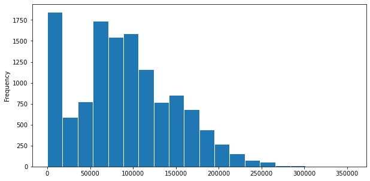

```python
salaries['Total Pay & Benefits'].plot(kind='hist', density=False, bins=20, ec='w');
```

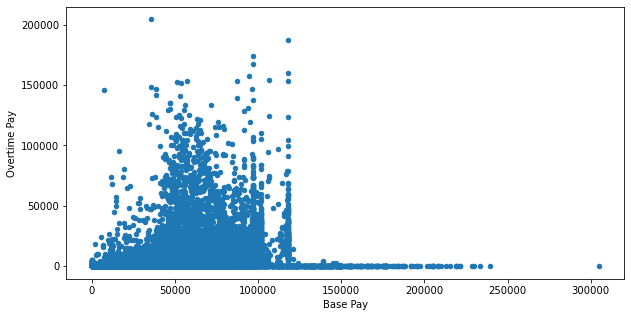

```python
salaries.plot(kind='scatter', x='Base Pay', y='Overtime Pay');
```

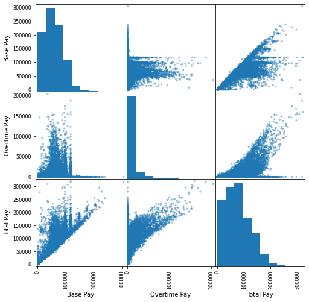

```python
pd.plotting.scatter_matrix(salaries[['Base Pay', 'Overtime Pay', 'Total Pay']], figsize=(8, 8));
```

Think of your own questions about the dataset, and try and answer them!

## Summary, next time

### Summary

- `pandas` relies heavily on `numpy`. An understanding of how data types work in both will allow you to write more efficient and bug-free code.
- Series and DataFrames share many methods (refer to the [`pandas` documentation](https://pandas.pydata.org/docs/user_guide/index.html#user-guide) for more details).
- Most `pandas` methods return **copies** of Series/DataFrames. Be careful when using techniques that modify values in-place.
- **Next time:** How to work with **messy data**.